# 冗余分析基础知识及操作步骤

2026-01-23

**作者**: 黄猇  
**邮箱**: xh_eco@outlook.com  
**地址**: 中国科学院武汉植物园

# 1 冗余分析 （Redundancy Analysis，RDA）的基本概念

## 1.1 用途

分析多个响应变量与多个解释变量之间的线性关系

## 1.2 原理

1. 每个响应变量做多元线性回归，解释变量作为预测因子，得到拟合值矩阵
2. 对拟合值矩阵进行 PCA，得到约束的主成分坐标（canonical axes）
3. 本质是**约束性**主成分分析（PCA)

## 1.3 前提

1. 响应变量与解释变量之间应该近似为线性关系
2. 解释变量之间不存在严重的共线性（VIF检验）
3. 数据尺度与量纲应该适当处理（包括响应变量和解释变量）

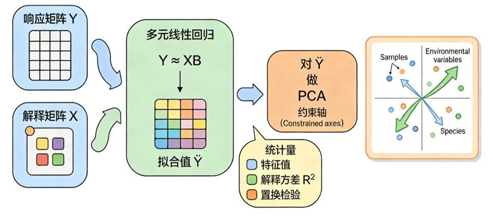

图1. 冗余分析的基本流程示意

# 2 实际例子

## 2.1 例1 微生物群落 × 环境因子

Markfeld, M., Titcomb, G., Randriamoria, T. M. et al. Differential assembly of core and non-core host-microbe network s along a land-use change gradient. Ecol Lett 28, no. 11: e70255. (2025). https://doi.org/10.1111/ele.70255

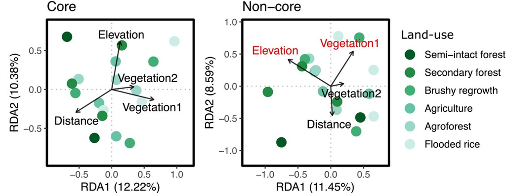

图2. 微生物群落结构对环境因子的响应

**Y**：样地 × 物种丰度  
**X**：海拔、植被类型、人类干扰程度

**生态问题**： 微生物群落如何随环境因子变化?

**RDA1**：代表影响物种丰度最主要的环境梯度  
**RDA2**：代表次要的环境梯度

**解读** 点的位置表示样点所处的环境条件  
物种和环境箭头表示影响群落结构的主因

## 2.2 例2 功能性状 × 环境因子

Joswig, J.S., Wirth, C., Schuman, M.C. et al. Climatic and soil factors explain the two-dimensional spectrum of global plant trait variation. Nat Ecol Evol 6, 36–50 (2022). https://doi.org/10.1038/s41559-021-01616-8

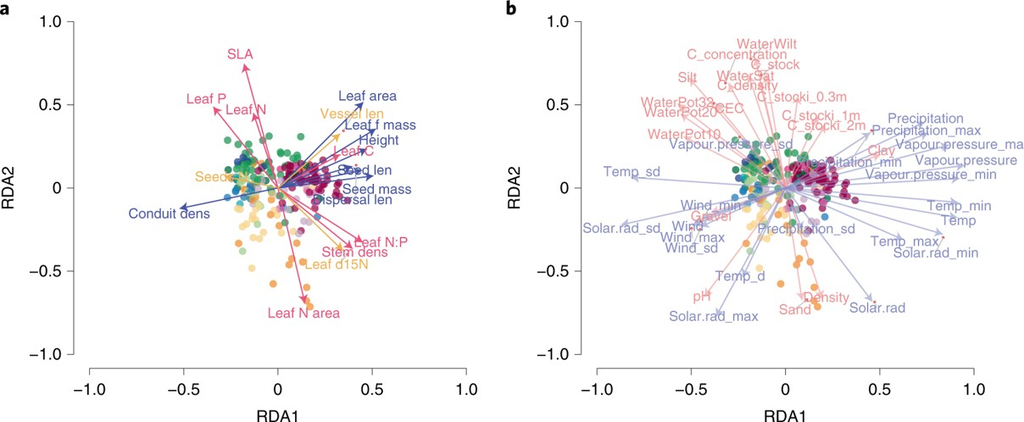

图3. 植物功能性状对环境因子的响应

**Y**：物种 × 功能性状  
**X**：温度、降水、实际蒸散发、土壤  
**生态问题**： 功能性状如何随环境因子变化？

**RDA1**：表示影响物种性状最主要的环境梯度  
**RDA2**：表示次要的环境梯度

**解读** 点的位置表示物种所处的环境条件  
性状与环境箭头表示影响功能性状的主因

# 3 操作流程

Huang, X., & Chen, S.-C. Fruit-type composition and climate drive latitudinal patterns in fruiting seasons across China. In preparation (2026).

## 3.1 分析

数据标准化

```r
RDA_indice <- indice %>%
  dplyr::select(divergence, evenness, M, S) %>%
  scale() %>%
  as.data.frame()

RDA_factors <- indice %>%
  dplyr::select(fleshy_pro, Actual_evapotranspiration, Annual_precipitation, Annual_mean_temperature, Precipitation_seasonality, Temperature_seasonality, frugivore_rich) %>%
  scale() %>%
  as.data.frame()
```

数据结构展示

```r
kable(head(RDA_indice), format = "html", caption = " 响应变量") %>%
  kable_styling(full_width = TRUE, bootstrap_options = c("striped", "hover"))
```

响应变量

| divergence | evenness | M | S |
| --- | --- | --- | --- |
| -0.2003016 | -0.0774041 | -0.5499634 | 0.5027393 |
| 0.1467786 | 0.1230368 | -0.2372204 | 0.5425816 |
| -0.3063591 | -1.1374871 | 0.1982608 | -0.7969160 |
| -0.4959326 | -0.0636144 | -0.7939629 | 0.1193009 |
| -0.5105820 | -0.3075445 | -0.5598463 | -0.1094432 |
| -0.7476620 | -1.0794366 | -0.0415549 | -1.1212420 |

```r
kable(head(RDA_factors), format = "html", caption = "解释变量") %>%
  kable_styling(full_width = TRUE, bootstrap_options = c("striped", "hover"))
```

解释变量

| fleshy_pro | Actual_evapotranspiration | Annual_precipitation | Annual_mean_temperature | Precipitation_seasonality | Temperature_seasonality | frugivore_rich |
| --- | --- | --- | --- | --- | --- | --- |
| -1.1697770 | -1.5670660 | -1.2206679 | -2.2311979 | 1.6238859 | -1.138370 | -0.9694856 |
| -1.6993990 | -1.1999637 | -0.9930658 | -1.6083809 | 1.1453536 | -2.014901 | -0.6079822 |
| -2.0377686 | -1.1490696 | -0.6581020 | -1.9672857 | 0.5726248 | -1.064932 | -0.7618214 |
| -1.3391991 | -1.0119290 | -0.9627184 | -1.3055462 | 0.8838743 | -1.592705 | -0.5881930 |
| -0.5827793 | -0.9547879 | -1.0537370 | -1.3174309 | 1.0958261 | -1.820216 | -0.7473804 |
| -2.0039316 | -0.5223735 | -0.6885813 | -0.9270054 | 1.1632728 | -1.831218 | -0.7298703 |

模型构建

```r
RDA <- rda(RDA_indice ~., RDA_factors, scale = TRUE)
```

置换检验

```r
per_test <- anova(RDA, permutations = 999)

kable(per_test, format = "html", caption = "") %>%
  kable_styling(full_width = TRUE, bootstrap_options = c("striped", "hover"))
```

|  | Df | Variance | F | Pr(>F) |
| --- | --- | --- | --- | --- |
| Model | 7 | 2.324806 | 18.4377 | 0.001 |
| Residual | 93 | 1.675194 | NA | NA |

VIF 共线性检验

```r
vif <- vif.cca(RDA)

vif.df <- data.frame(
  Variable = names(vif),
  VIF = as.numeric(vif)
)

kable(vif.df, format = "html", col.names = c("Environmental variable", "VIF")) %>%
  kable_styling(full_width = TRUE)
```

| Environmental variable | VIF |
| --- | --- |
| fleshy_pro | 1.612098 |
| Actual_evapotranspiration | 7.122721 |
| Annual_precipitation | 6.922872 |
| Annual_mean_temperature | 6.040587 |
| Precipitation_seasonality | 3.869459 |
| Temperature_seasonality | 2.190566 |
| frugivore_rich | 2.497709 |

相对重要性分解

```r
mite.rda.hp <- rdacca.hp(RDA_indice, RDA_factors, scale = TRUE, method = 'RDA', type = 'R2')
kable(mite.rda.hp$Hier.part, "html") %>%
  kable_styling(latex_options = c("striped", "hold_position"))
```

|  | Unique | Average.share | Individual | I.perc(%) |
| --- | --- | --- | --- | --- |
| fleshy_pro | 0.0252 | 0.0298 | 0.0550 | 9.47 |
| Actual_evapotranspiration | 0.0223 | 0.1107 | 0.1330 | 22.89 |
| Annual_precipitation | 0.0103 | 0.0757 | 0.0860 | 14.80 |
| Annual_mean_temperature | 0.0090 | 0.0945 | 0.1035 | 17.81 |
| Precipitation_seasonality | 0.0681 | 0.0237 | 0.0918 | 15.80 |
| Temperature_seasonality | 0.0054 | 0.0433 | 0.0487 | 8.38 |
| frugivore_rich | 0.0061 | 0.0571 | 0.0632 | 10.88 |

## 3.2 可视化

提取排序结果数据

```r
rda_scores <- scores(RDA, display = c("sites", "species"))
sites_scores <- as.data.frame(rda_scores$sites)
colnames(sites_scores) <- c("RDA1", "RDA2")  # 重命名坐标轴
sites_scores$latitude <- indice$latitude

species_scores <- as.data.frame(rda_scores$species)
colnames(species_scores) <- c("RDA1", "RDA2")

env_scores <- as.data.frame(RDA$CCA$biplot[,1:2])
colnames(env_scores) <- c("RDA1", "RDA2")

kable(env_scores, "html") %>%
  kable_styling(latex_options = c("striped", "hold_position"))
```

|  | RDA1 | RDA2 |
| --- | --- | --- |
| fleshy_pro | 0.5758926 | -0.2753991 |
| Actual_evapotranspiration | 0.9406039 | 0.2951071 |
| Annual_precipitation | 0.7705983 | 0.5176117 |
| Annual_mean_temperature | 0.8898308 | 0.2129737 |
| Precipitation_seasonality | -0.4791076 | -0.7461993 |
| Temperature_seasonality | 0.6909998 | 0.0400907 |
| frugivore_rich | 0.7404731 | -0.0596328 |

绘图

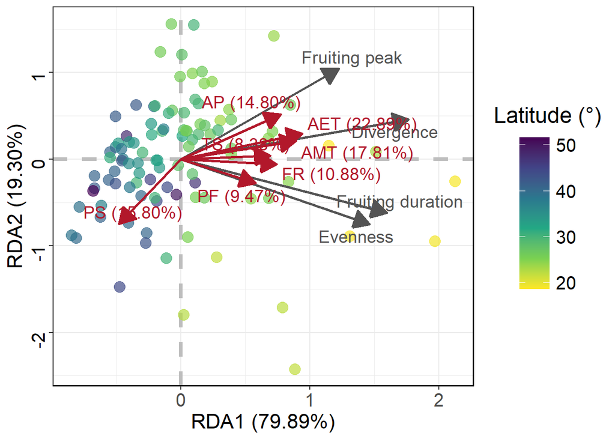

```r
require(ggrepel)
RDA_fig <- ggplot() +

  # 添加X轴和Y轴
  geom_hline(yintercept = 0, linetype = "dashed", color = "grey", size = 1.5) +
  geom_vline(xintercept = 0, linetype = "dashed", color = "grey", size = 1.5) +
  # 绘制样本点
  geom_point(data = sites_scores, aes(x = RDA1, y = RDA2, colour = latitude), size = 4, alpha = 0.7) +
  scale_color_viridis_c(direction = -1) +
  # 绘制物种箭头（带箭头的线）
  geom_segment(data = species_scores, aes(x = 0, y = 0, xend = RDA1, yend = RDA2),
               arrow = arrow(type = "closed", length = unit(0.2, "inches")),
               color = "grey33", size = 1) +
  # 添加物种标签
  geom_text_repel(data = species_scores, aes(x = RDA1, y = RDA2, label = c("Divergence", 'Evenness', "Fruiting peak", "Fruiting duration")), size = 5, color =  "grey33") +

  # 绘制环境因子箭头
  geom_segment(data = env_scores, aes(x = 0, y = 0, xend = RDA1, yend = RDA2),
               arrow = arrow(type = "closed", length = unit(0.2, "inches")),
               color = "#B2182B", size = 1) +
  # 添加环境因子标签
  geom_text_repel(data = env_scores, aes(x = RDA1, y = RDA2, label = c("PF (9.47%)", "AET (22.89%)", "AP (14.80%)", 'AMT (17.81%)', "PS (15.80%)", "TS (8.38%)", "FR (10.88%)")), size = 5, color = "#B2182B") +
  theme_bw() +
  labs(y = "RDA2 (19.30%)") +
  labs(x = "RDA1 (79.89%)",
       colour = 'Latitude (°)') +
  theme_bw() +
  theme(plot.title =  element_text(size = 15),
        panel.border = element_rect(size = 0.8, color = "black"),
        legend.text = element_text( size = 15),
        legend.key.size = unit(25, "pt"),

        legend.title = element_text(
          size = 18,
          hjust = 0.5,
          margin = margin(b = 10)),

        axis.title = element_text(size = 17),
        axis.text.x = element_text(size = 15),
        axis.text.y = element_text(size = 15, angle = 90, hjust = 1, color = "black"))
```

图4. 冗余分析（RDA）图展示果实季节性特征与生态因子之间的关系